# STAT 302 SPR2020 Lecture 14

Sheridan Grant

May 13, 2020

## Preliminaries

Libraries:

```r
library(tidyverse)
```

Helper functions:

```r
# e^x/(e^x+1) for input x
expit <- function(x) exp(x)/(exp(x) + 1)

# root mean squared error for true y and prediction yhat
rmse <- function(y,yhat) sqrt(mean((y-yhat)^2))

# mean absolute error for true y and prediction yhat
mae <- function(y,yhat) mean(abs(y-yhat))

# accuracy for predictions yhat and true binary outcome y
acc <- function(y, yhat) mean(y == yhat)
```

SAT data

```r
sat <- read.csv('../data/sat.csv')
colnames(sat)
```

```
## [1] "ï..sex" "SATV"   "SATM"   "SATSum" "HSGPA"  "FYGPA"
```

```r
colnames(sat)[1] <- 'sex'
sat$sex <- sat$sex - 1  # 0/1 is conventional, data gives 1/2
n <- dim(sat)[1]
```

## Logistic Regression Toy Example

Suppose we’re interested in whether or not freshmen get the “UW pass” (2.0) GPA.

```r
linMod <- lm(FYGPA ~ SATSum, data = sat)

sat$pass <- sat$FYGPA >= 2
logitMod <- glm(pass ~ SATSum, data = sat,
                family = 'binomial')  # binomial tells glm to do logistic reg.

head(predict(linMod))
```

```
##        1        2        3        4        5        6
## 3.032876 2.913547 2.770353 2.269172 2.555561 2.651024
```

```r
head(predict(logitMod, type = 'response'))
```

```
##         1         2         3         4         5         6
## 0.9264288 0.9049352 0.8718672 0.6775420 0.8043911 0.8372342
```

Linear Regression analysis:

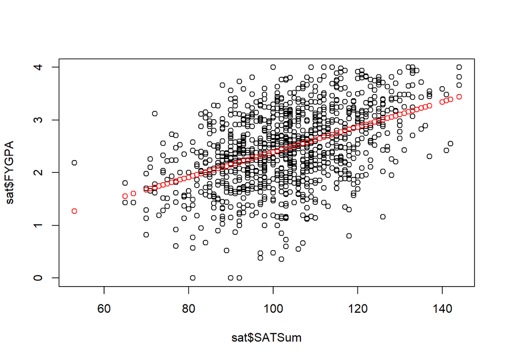

```r
plot(sat$SATSum, sat$FYGPA)
points(sat$SATSum, predict(linMod), col = 'red')
```

Logistic Regression analysis:

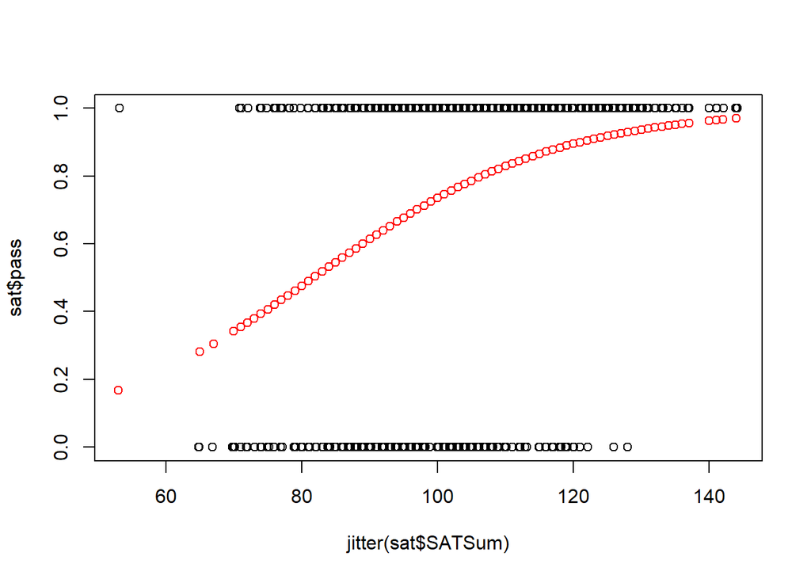

```r
plot(jitter(sat$SATSum), sat$pass)  # jitter shows density for discrete vals
points(sat$SATSum, predict(logitMod, type = 'response'), col = 'red')
```

### Estimated probabilities

Linear Regression analysis:

```r
x <- 160
coef(linMod)[1] + coef(linMod)[2]*x
```

```
## (Intercept)
##    3.820445
```

```r
predict(linMod, data.frame(SATSum = x))
```

```
##        1
## 3.820445
```

Logistic Regression analysis:

```r
coef(logitMod)[1] + coef(logitMod)[2]*x
```

```
## (Intercept)
##    4.379626
```

```r
predict(logitMod, data.frame(SATSum = x))
```

```
##        1
## 4.379626
```

```r
expit(coef(logitMod)[1] + coef(logitMod)[2]*x)
```

```
## (Intercept)
##    0.987625
```

```r
predict(logitMod, data.frame(SATSum = x), type = 'response')
```

```
##        1
## 0.987625
```

### Model Fitting

Linear Regression analysis:

```r
summary(linMod)
```

```
##
## Call:
## lm(formula = FYGPA ~ SATSum, data = sat)
##
## Residuals:
##     Min      1Q  Median      3Q     Max
## -2.1976 -0.4495  0.0315  0.4557  1.6115
##
## Coefficients:
##             Estimate Std. Error t value Pr(>|t|)
## (Intercept) 0.001927   0.151991   0.013     0.99
## SATSum      0.023866   0.001457  16.379   <2e-16 ***
## ---
## Signif. codes:  0 '***' 0.001 '**' 0.01 '*' 0.05 '.' 0.1 ' ' 1
##
## Residual standard error: 0.658 on 998 degrees of freedom
## Multiple R-squared:  0.2119, Adjusted R-squared:  0.2111
## F-statistic: 268.3 on 1 and 998 DF,  p-value: < 2.2e-16
```

Residual standard error tells you about the model fit, is a function of the optimal sum of squares found by the optimization routine. df tells you about size/complexity of the model.

Logistic Regression analysis:

```r
summary(logitMod)
```

```
##
## Call:
## glm(formula = pass ~ SATSum, family = "binomial", data = sat)
##
## Deviance Residuals:
##     Min       1Q   Median       3Q      Max
## -2.3071  -0.9142   0.5810   0.7840   1.8922
##
## Coefficients:
##              Estimate Std. Error z value Pr(>|z|)
## (Intercept) -4.573303   0.598633   -7.64 2.18e-14 ***
## SATSum       0.055956   0.006017    9.30  < 2e-16 ***
## ---
## Signif. codes:  0 '***' 0.001 '**' 0.01 '*' 0.05 '.' 0.1 ' ' 1
##
## (Dispersion parameter for binomial family taken to be 1)
##
##     Null deviance: 1137.7  on 999  degrees of freedom
## Residual deviance: 1035.6  on 998  degrees of freedom
## AIC: 1039.6
##
## Number of Fisher Scoring iterations: 4
```

Residual deviance tells you about the model fit, is a function of the *objective* minimized by the optimization routine. df tells you about size/complexity, Fisher Scoring is the optimization technique.

### Prediction

Here’s some fake new data:

```r
test <- data.frame(FYGPA = c(1.8, 2, 2.5),
                   pass = c(0,1,1),
                   SATSum = c(110, 95, 115),
                   HSGPA = c(2.0, 2.0, 2.0))
```

Linear Regression analysis:

```r
rmse(test$FYGPA, predict(linMod, test))
```

```
## [1] 0.5219835
```

```r
rmse(test$FYGPA, predict(lm(FYGPA ~ HSGPA, data = sat), test))
```

```
## [1] 0.5996439
```

```r
mae(test$FYGPA, predict(linMod, test))
```

```
## [1] 0.4476059
```

```r
mae(test$FYGPA, predict(lm(FYGPA ~ HSGPA, data = sat), test))
```

```
## [1] 0.5224042
```

Logistic Regression analysis:

```r
f1 <- function(x) x > 0.5
f2 <- function(x) x > 0.7

acc(test$pass, f1(predict(logitMod, test, type = 'response')))
```

```
## [1] 0.6666667
```

```r
acc(test$pass, f2(predict(logitMod, test, type = 'response')))
```

```
## [1] 0.3333333
```

## Practical Example: Senate Voting Behavior

We know how to handle binary and categorical predictor variables. How about outcomes?

```r
votes115 <- read_csv('../data/S115_votes.csv')
members115 <- read_csv('../data/S115_members.csv')
joint115 <- inner_join(votes115, members115, by = 'icpsr')  # link records on senator ID
joint115 %>% filter(!is.na(nominate_dim1), !is.na(nominate_dim2)) -> joint115
unique(joint115$cast_code)
```

```
## [1] 1 6 9 7
```

```r
joint115 <- joint115 %>% filter(cast_code %in% c(1,6),
                                party_code %in% c(100,200))
joint115$party <- ifelse(joint115$party_code == 100, 'D', 'R')
joint115$yay <- (joint115$cast_code == 1)
n <- dim(joint115)[1]
```

How likely are senators from each party to vote to pass bills? 115th congress (2017-2019).

```r
# Logistic regression
partyMod <- glm(yay ~ party, data = joint115, family = 'binomial')
summary(partyMod)
```

```
##
## Call:
## glm(formula = yay ~ party, family = "binomial", data = joint115)
##
## Deviance Residuals:
##     Min       1Q   Median       3Q      Max
## -1.9098  -1.1718   0.5934   0.5934   1.1830
##
## Coefficients:
##             Estimate Std. Error z value Pr(>|z|)
## (Intercept) -0.01316    0.01213  -1.085    0.278
## partyR       1.66083    0.01985  83.675   <2e-16 ***
## ---
## Signif. codes:  0 '***' 0.001 '**' 0.01 '*' 0.05 '.' 0.1 ' ' 1
##
## (Dispersion parameter for binomial family taken to be 1)
##
##     Null deviance: 71981  on 57123  degrees of freedom
## Residual deviance: 64165  on 57122  degrees of freedom
## AIC: 64169
##
## Number of Fisher Scoring iterations: 3
```

Which party controlled the Senate 2017-2019?

What do the coefficient estimates mean?

```r
cat('Prob D votes yay:', expit(coef(partyMod)[1]),
    '\nProb R votes yay:', expit(sum(coef(partyMod))), '\n\n')
```

```
## Prob D votes yay: 0.4967106
## Prob R votes yay: 0.838576
```

We didn’t need a fancy model for this, actually:

```r
joint115 %>% group_by(party) %>% summarize(yayProb = mean(yay))
```

```
## # A tibble: 2 x 2
##   party yayProb
##   <chr>   <dbl>
## 1 D       0.497
## 2 R       0.839
```

It gets interesting when continuous covariates are included:

```r
nomMod <- glm(yay ~ nominate_dim1*nominate_dim2,
              data = joint115, family = 'binomial')
summary(nomMod)
```

```
##
## Call:
## glm(formula = yay ~ nominate_dim1 * nominate_dim2, family = "binomial",
##     data = joint115)
##
## Deviance Residuals:
##    Min      1Q  Median      3Q     Max
## -2.211  -1.122   0.586   0.821   1.536
##
## Coefficients:
##                             Estimate Std. Error z value Pr(>|z|)
## (Intercept)                  0.70765    0.01041   67.96  < 2e-16 ***
## nominate_dim1                1.88239    0.02644   71.19  < 2e-16 ***
## nominate_dim2                0.57395    0.03928   14.61  < 2e-16 ***
## nominate_dim1:nominate_dim2  0.37326    0.09547    3.91 9.23e-05 ***
## ---
## Signif. codes:  0 '***' 0.001 '**' 0.01 '*' 0.05 '.' 0.1 ' ' 1
##
## (Dispersion parameter for binomial family taken to be 1)
##
##     Null deviance: 71981  on 57123  degrees of freedom
## Residual deviance: 63878  on 57120  degrees of freedom
## AIC: 63886
##
## Number of Fisher Scoring iterations: 4
```

### Prediction and Extrapolation

```r
ind <- sample(n)
nTrain <- floor(n/2)
train115 <- joint115[ind[1:nTrain],]
test115 <- joint115[ind[(nTrain+1):n],]

trainParty <- glm(yay ~ party, data = train115, family = 'binomial')
trainNom <- glm(yay ~ nominate_dim1*nominate_dim2,
                data = train115, family = 'binomial')

acc(test115$yay, f1(predict(trainParty, test115, type = 'response')))
```

```
## [1] 0.6770534
```

```r
acc(test115$yay, f1(predict(trainNom, test115, type = 'response')))
```

```
## [1] 0.7103844
```

Predict for a different congress (103rd, 1993-1995). Extrapolation or no?

```r
votes103 <- read_csv('../data/S103_votes.csv')
members103 <- read_csv('../data/S103_members.csv')
joint103 <- inner_join(votes103, members103, by = 'icpsr')
dim(joint103)
```

```
## [1] 73124    27
```

```r
unique(joint103$cast_code)
```

```
## [1] 1 6 9 7
```

```r
joint103 <- joint103 %>% filter(cast_code %in% c(1,6),
                                party_code %in% c(100,200))
joint103$party <- ifelse(joint103$party_code == 100, 'D', 'R')
joint103$yay <- (joint103$cast_code == 1)
```

Extrapolation accuracy. Using our knowledge that yays are more likely than nays when the same party controls the House and Senate (House sends bills to the Senate), we can improve the accuracy by always guessing “1”–our models and accuracy metric could use improvement…

```r
predProbsParty <- expit(predict(partyMod, joint103))
acc(joint103$yay, f1(predProbsParty))
```

```
## [1] 0.3865581
```

```r
predProbsNom <- expit(predict(nomMod, joint103))
acc(joint103$yay, f1(predProbsNom))
```

```
## [1] 0.5536544
```

```r
mean(joint115$yay)
```

```
## [1] 0.6757405
```

```r
acc(joint103$yay, 1)
```

```
## [1] 0.643796
```

## Plot Generating for Slides

In case you’re curious how I make slides.

Linear regression:

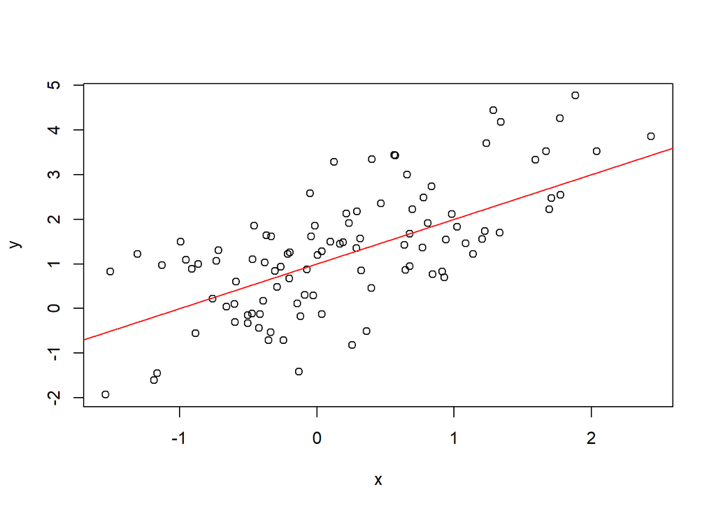

```r
x <- rnorm(100)
y <- 1 + x + rnorm(100)
plot(x, y, main = '')
abline(1, 1, col = 'red')
```

Logistic regression:

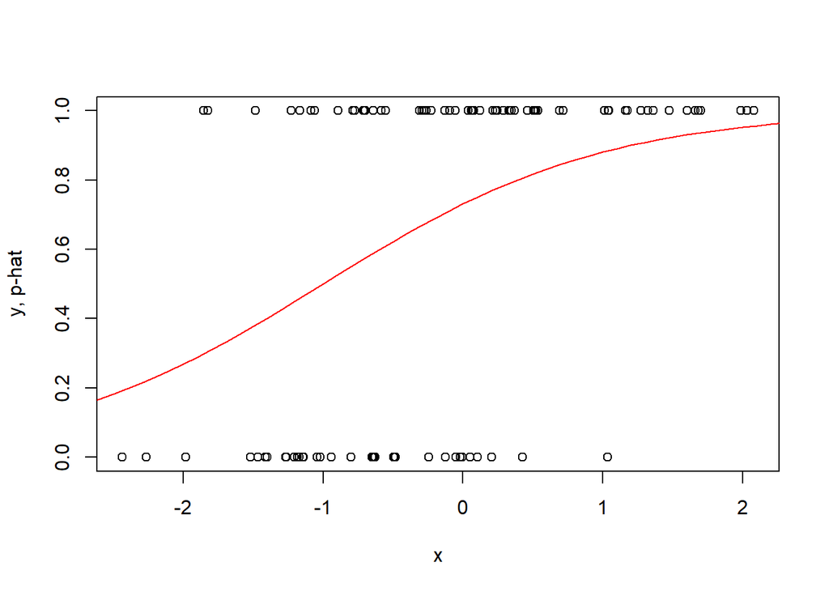

```r
x <- rnorm(100)
probs <- expit(1 + x + rnorm(100))
y <- rbinom(100, 1, probs)
plot(x, y, main = '', ylab = 'y, p-hat')
lines(seq(-3,3,.1), expit(1 + seq(-3,3,.1)), col = 'red')
```